# L05-4-Graphic-Functions

## Assignment Instructions

Rename with your name in place of Studentname and make your edits and updates here.

# Managing Graphics Code

In this exercise, you organize your code by creating your own functions. This reduces code duplication and enhances readability. Once you have your code in functions, you can call this code using for loops.

ggplot can generate a lot of duplicate code. Wrapping ggplot code into functions can help reduce code duplication. Calling these functions using loops or functional iterators can make creating a variety of charts quick and easy to help explore your data more effectively.

## R Features

- library()
- glimpse()
- ggplot()
- aes()
- aes_string()
- geom_jitter()
- geom_smooth()
- ggtitle()
- print()
- c()
- for()
- walk()
- names()
- str_detect()
- ggsave()

## Datasets

- mtcars

```r
# Load libraries
library(stringr)    # stringr
library(tidyverse)  # tidyverse
library(repr)
```

Let's start with some ggplot code

```
Observations: 32
Variables: 11
$ mpg  <dbl> 21.0, 21.0, 22.8, 21.4, 18.7, 18.1, 14.3, 24.4, 22.8, 19.2, 17...
$ cyl  <dbl> 6, 6, 4, 6, 8, 6, 8, 4, 4, 6, 6, 8, 8, 8, 8, 8, 8, 4, 4, 4, 4,...
$ disp <dbl> 160.0, 160.0, 108.0, 258.0, 360.0, 225.0, 360.0, 146.7, 140.8,...
$ hp   <dbl> 110, 110, 93, 110, 175, 105, 245, 62, 95, 123, 123, 180, 180, ...
$ drat <dbl> 3.90, 3.90, 3.85, 3.08, 3.15, 2.76, 3.21, 3.69, 3.92, 3.92, 3....
$ wt   <dbl> 2.620, 2.875, 2.320, 3.215, 3.440, 3.460, 3.570, 3.190, 3.150,...
$ qsec <dbl> 16.46, 17.02, 18.61, 19.44, 17.02, 20.22, 15.84, 20.00, 22.90,...
$ vs   <dbl> 0, 0, 1, 1, 0, 1, 0, 1, 1, 1, 1, 0, 0, 0, 0, 0, 0, 1, 1, 1, 1,...
$ am   <dbl> 1, 1, 1, 0, 0, 0, 0, 0, 0, 0, 0, 0, 0, 0, 0, 0, 0, 1, 1, 1, 0,...
$ gear <dbl> 4, 4, 4, 3, 3, 3, 3, 4, 4, 4, 4, 3, 3, 3, 3, 3, 3, 4, 4, 4, 3,...
$ carb <dbl> 4, 4, 1, 1, 2, 1, 4, 2, 2, 4, 4, 3, 3, 3, 4, 4, 4, 1, 2, 1, 1,...
```

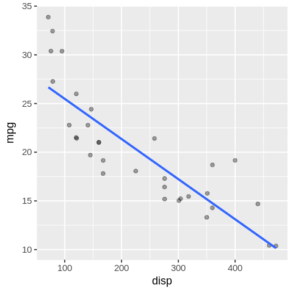

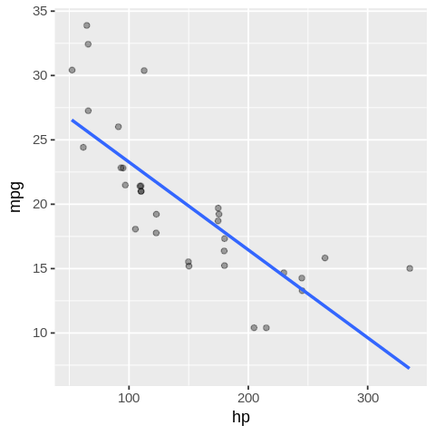

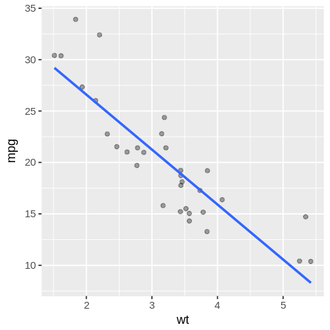

```r
# Glimpse mtcars data
mtcars %>% glimpse()

# mtcars: y axis: mpg, x axis: disp
# +jitter; +alpha; +linear trend no se
options(repr.plot.width=4, repr.plot.height=4)
mtcars %>% ggplot(mapping = aes(x = disp, y = mpg)) +
   geom_jitter(alpha = 0.35) +
   geom_smooth(method = "lm", se = FALSE)

# mtcars: y axis: mpg, x axis: hp
# +jitter; +alpha; +linear trend no se
mtcars %>% ggplot(mapping = aes(x = hp, y = mpg)) +
   geom_jitter(alpha = 0.35) +
   geom_smooth(method = "lm", se = FALSE)

# mtcars: y axis: mpg, x axis: wt
# +jitter; +alpha; +linear trend no se
mtcars %>% ggplot(mapping = aes(x = wt, y = mpg)) +
   geom_jitter(alpha = 0.35) +
   geom_smooth(method = "lm", se = FALSE)
```

Notice that most of the code is repeated for each chart. Also, it might be helpful to have a chart title to make it easier to distinguish between them.

Let's add the chart title first.

## ggtitle()

Modify axis, legend, and plot labels. Good labels are critical for making your plots accessible to a wider audience. Ensure the axis and legend labels display the full variable name. Use the plot title and subtitle to explain the main findings. It's common to use the caption to provide information about the data source.

### Usage

ggtitle(label, subtitle = NULL)

```r
# View help on ggtitle()
?ggtitle
```

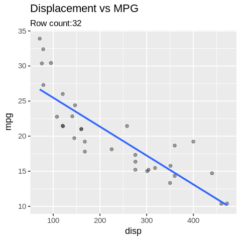

```r
# mtcars:
#    y axis: mpg,
#    x axis: disp
# +jitter;
# +alpha;
# +linear trend no se
# Title:
#    <y axis> vs <x axis>
# Subtitle:
#    Row count: <nrows>
# Hint: ggtitle(), nrow()

mtcars %>% ggplot(mapping = aes(x = disp, y = mpg)) +
   geom_jitter(alpha = 0.35) +
   geom_smooth(method = "lm", se = FALSE) +
   ggtitle("Displacement vs MPG",
          subtitle = str_c("Row count:", mtcars %>% nrow()))
```

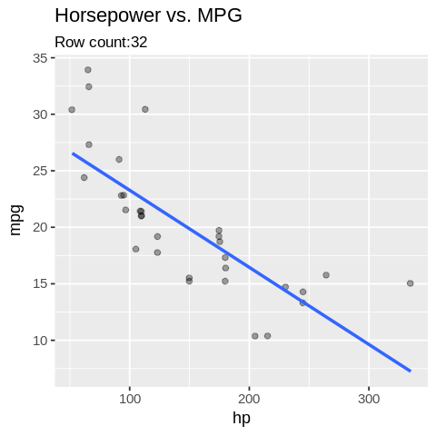

```r
# mtcars: y axis: mpg, x axis: hp
# +jitter; +alpha; +linear trend no se
mtcars %>% ggplot(mapping = aes(x = hp, y = mpg)) +
   geom_jitter(alpha = 0.35) +
   geom_smooth(method = "lm", se = FALSE)+
   ggtitle("Horsepower vs. MPG",
          subtitle = str_c("Row count:", mtcars %>% nrow()))
```

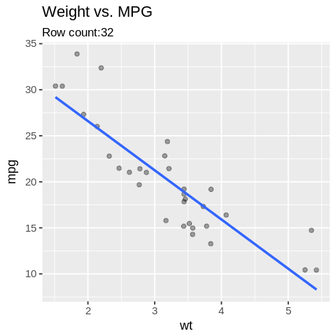

```r
# mtcars: y axis: mpg, x axis: wt
# +jitter; +alpha; +linear trend no se
mtcars %>% ggplot(mapping = aes(x = wt, y = mpg)) +
   geom_jitter(alpha = 0.35) +
   geom_smooth(method = "lm", se = FALSE)+
   ggtitle("Weight vs. MPG",
          subtitle = str_c("Row count:", nrow(mtcars) ))
```

Let's wrap the ggplot code into a function.

## aes_string()

Define aesthetic mappings programmatically. Aesthetic mappings describe how variables in the data are mapped to visual properties (aesthetics) of geoms. aes uses non-standard evaluation to capture the variable names. aes_ and aes_string require you to explicitly quote the inputs either with "" for aes*string(), or with quote or ~ for aes*(). (aes*q is an alias to aes*). This makes aes_ and aes_string easy to program with.

### Usage

aes_string(x, y, ...)

```r
# View help on aes_string()
?aes_string
```

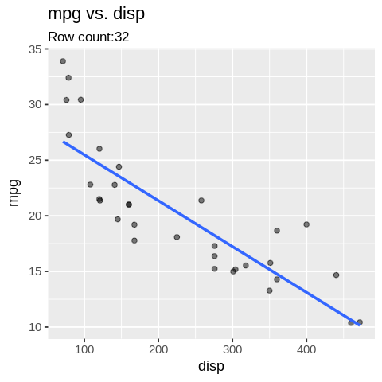

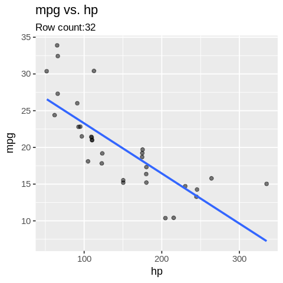

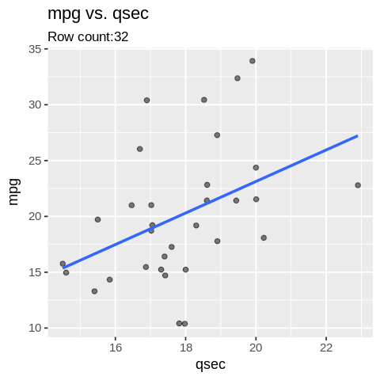

```r
# Create function gg_scatter
# Pass in data frame as data
# and x_col, y_col as strings for x and y axis columns
# Match functionality of prior code block
# Hint: aes_string()
gg_scatter <- function(data, x_col, y_col) {
    plt <- data %>% ggplot(mapping = aes_string(x = x_col, y = y_col)) +
       geom_jitter(alpha = 0.5) +
       geom_smooth(method = "lm", se = FALSE) +
       ggtitle(str_c(y_col, " vs. ", x_col),
              subtitle = str_c("Row count:", data %>% nrow()))
    print(plt)
}

# Call function for disp, hp, and wt all vs mpg
gg_scatter(mtcars, "disp", "mpg")
mtcars %>% gg_scatter("hp", "mpg")
mtcars %>% gg_scatter("qsec", "mpg")
```

Notice that not only is the ggplot code reused, but it is easier to understand your code with three short function calls instead of three large blocks of ggplot code.

Let's use a For loop to simplify more.

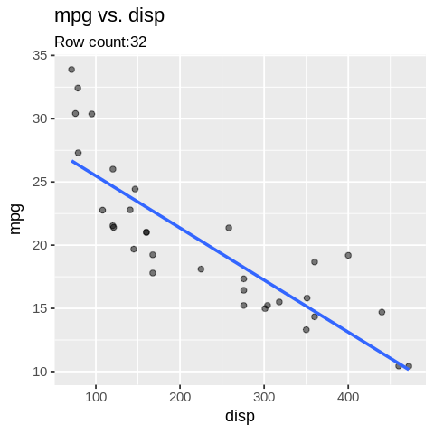

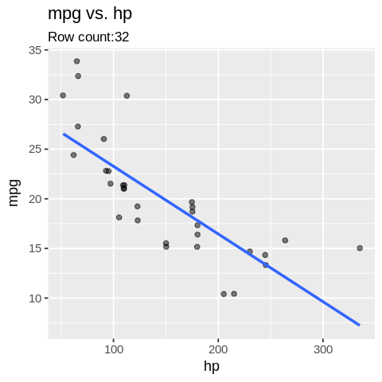

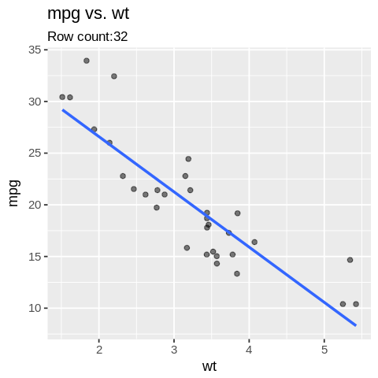

```r
# Define the x axis columns in
# a character vector x_cols
# for disp, hp, and wt
# Hint: c()
x_cols <- c("disp", "hp", "wt")

# Create a for loop and call gg_scatter
# Use mtcars, x_cols, and "mpg"
for(x_col in x_cols) {
    gg_scatter(mtcars, x_col, "mpg")}
```

Notice the for loop makes it a bit more concise and easier to update the list of columns to plot.

Let's change the For loop to a walk() functional.

## Walk()

Apply a function to each element of a vector. map() returns the transformed input; walk() calls .f for its side-effect and returns the original input. map() returns a list or a data frame; map_lgl(), map_int(), map_dbl() and map_chr() return vectors of the corresponding type (or die trying); map_df() returns a data frame by row-binding the individual elements.

### Usage

walk(.x, .f, ...)

```r
# View help on walk()
#?walk()
x_cols <- c("disp", "hp", "wt")

print_me <- function(label) {
    print(label)
}

x_cols %>% walk(print_me)

walk(x_cols, print_me)
```

```
[1] "disp"
[1] "hp"
[1] "wt"
[1] "disp"
[1] "hp"
[1] "wt"
```

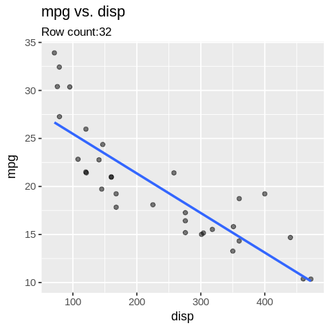

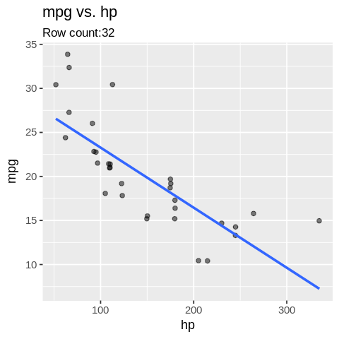

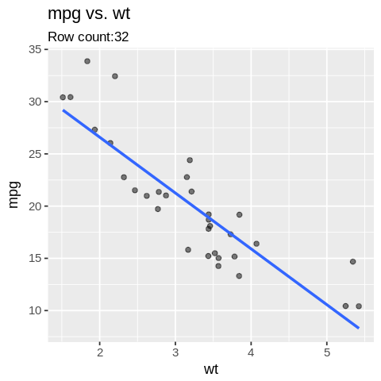

```r
# Define the x axis columns in
# a character vector x_cols
# for disp, hp, and wt
# Hint: c()
x_cols <- c("disp", "hp", "wt")

# Create a functional call to iterate over the objects
# Hint: walk()

#x_cols %>% walk(gg_scatter, data = mtcars, y_col = "mpg")
# Can also be written as below:
walk(x_cols, gg_scatter, data = mtcars, y_col = "mpg")
```

```r
?select
```

Notice that the For loop is now a single line of code.

Let's make the x_cols more dynamic and plot all the columns from mtcars.

```
 [1] "cyl"  "disp" "hp"   "drat" "wt"   "qsec" "vs"   "am"   "gear" "carb"
```

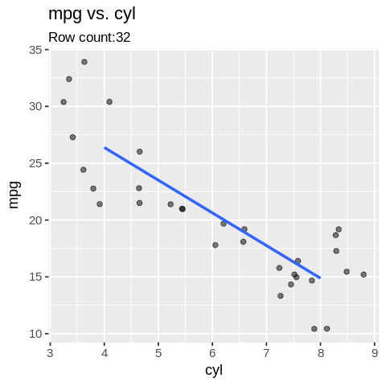

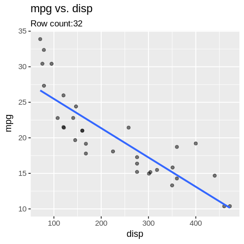

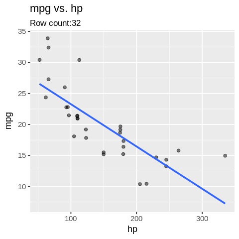

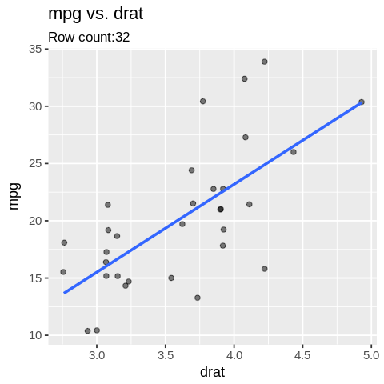

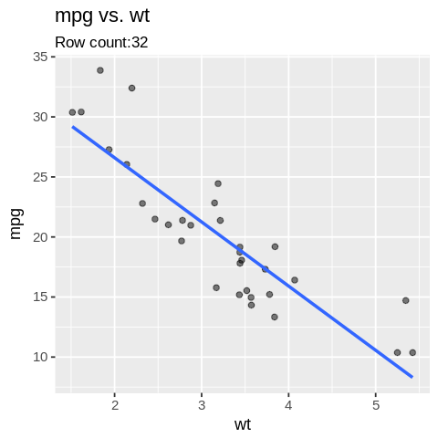

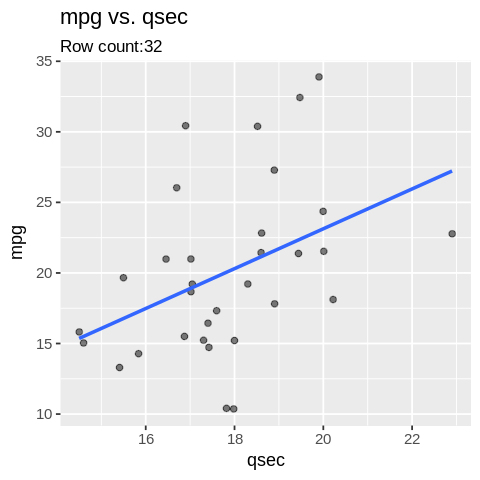

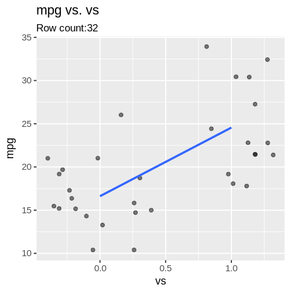

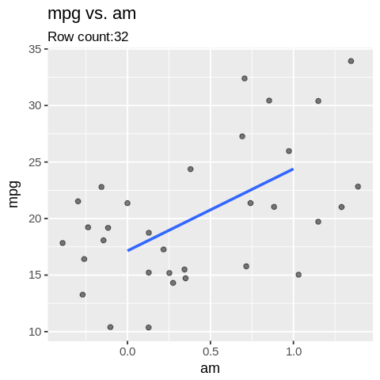

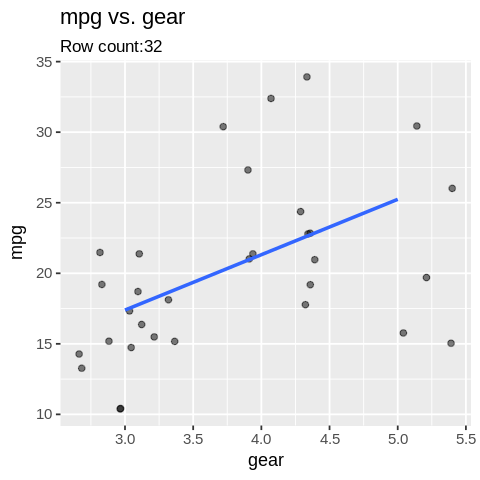

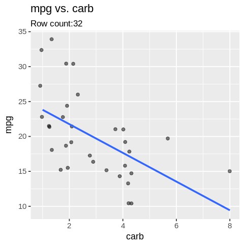

```r
# Define y axis column as y_col
# y axis column is mpg
y_col <- "mpg"

# Define the x axis columns in
# a character vector x_cols
# for all columns in mtcars
# Hint: names()
x_cols <- names(mtcars)

# Remove y_axis column from x_cols
# Hint: !str_detect()
#x_cols <- x_cols[-y_col]

x_cols <- x_cols[-str_detect(x_cols, y_col)]


# Print x columns
print(x_cols)

# Create a functional call to iterate over the objects
# Calling gg_scatter with mtcars and x and y columns
# Hint: walk()
#x_cols %>% walk(gg_scatter, data = mtcars, y_col = y_col)
# aka
walk(x_cols, gg_scatter, data = mtcars, y_col)
```

Notice, that you can let the data in the data frame drive most of the exploration and creation of charts.

It might be nice to save the charts as images on disk for later use. Let's add this as a function.